# Presentazione

26-06-2023

## Contesto e domande poste

Dal 1957 in poi gli esseri umani hanno cercato di lanciare missili verso altri astri. Alla luce di ciò, mi sono chiesto:

1. Quali sono i paesi con il maggior numero di lanci?
2. Quanti di questi lanci sono andati a buon fine? Quanti no?

## Obiettivi

1. Capire quali sono le nazioni che si sono impegnati di più in questo determinato campo.
2. Analizzare se effettivamente i lanci missilistici sono risultati utili o se si sono rivelati uno spreco di tempo e risorse.

## Breve introduzione del dataset

Il dataset utilizzato è il seguente:  
-[**“Space Mission Launches”**](https://www.kaggle.com/datasets/sefercanapaydn/mission-launches) scaricato gratuitamente dal sito web di [kaggle](https://www.kaggle.com/).  
Il dataset contiene dati relativi ai lanci missilistici avvenuti dal 1957 al 2020.

[figure not shown]

## Struttura dataset

Vi sono 9 colonne :  
**1.** **Id:** un identificatore per ogni riga del dataset.  
**2.** **Organisation:** nome dell’organizzazione che effettua lancio.  
**3.** **Location:** luogo da dove hanno effettuato il lancio missilistico.  
**4.** **Date:** data del lancio missilistico.  
**5.** **Detail:** tipo di razzo utilizzato.  
**6.** **Price:** il prezzo in milioni del lancio.  
**7.** **Mission_Status:** l’esito che il lancio missilistico ha assunto.

Le due colonne mancanti non sono state usate perchè non sarebbero servite alla mia analisi e sono: una seconda colonna Id tolta per rindondanza della prima colonna, la seconda colonna tolta è la seguente “Rocket_Status” non usata perchè nella mia analisi non sarebbe servita.

## Analisi effettuate

**Analisi uno**  
Realizzazione di una cartina geografica colorata con una tonalità più scura a seconda del numero di lanci effettuati da quel determinato paese.

**Analisi due**  
Realizzazione di un grafico a barre anch’esso colorato usando colori diversi in base all’esito della missione per ogni anno partendo dal 1957 fino ad arrivare al 2020.

## Codice sorgente della prima analisi

```r
library(dplyr)
library(stringr)
library(ggplot2)
library(ggmap)
library(tidyr)

#Dataset originali di partenza
map.world = map_data("world")
originalDataset = read.csv("mission_launches.csv")

#Serie di mutate per estrarre il nome della nazione
df = originalDataset %>%
  mutate(Country =str_split_i(originalDataset$Location, ',',-1))%>%
  mutate(Country = str_trim(Country))

#Conta il numero di volte che un paese compare nel dataset e li ordina in modo decrescente
df_country = df %>%
  group_by(Country) %>%
  summarise(n = n()) %>%
  arrange(-n)


#left join per ottenere la longitudine e latitudine nella libreria map_data("world") per il geom_polygon
map.world_joined = left_join( map.world, df_country,  by = c( 'region' = 'Country'))
map.world_joined = map.world_joined %>%
  mutate( n = replace_na(n, 0)) #rimpiazza il valore na con uno 0, usa il valoe n se è diverso da 0#

#Cambio il tipo dei dati nella colonna n creata col mutate
map.world_joined$n = as.numeric(map.world_joined$n)


#Plotta il dataset map.world_joined creando una cartina geografica usando longitudine e latitudine
# colorando i paesi in colori diversi in base a quante volte compaiono nel dataset (ovvero hanno eseguito diversi lanci missilistici)
ggplot() +
  geom_polygon(data = map.world_joined, aes(x = long, y = lat, group = group, fill = n)) +
  scale_fill_gradient(low = "#abdbe3", high = "#154c79") +
  labs(title = "Lanci missilistici nel mondo", y="Latitudine", x="Longitudine") +
  theme(text = element_text(color = "black",)
    ,panel.background = element_rect(fill ="#FaFFFF")
    ,plot.background = element_rect(fill = "white")
    ,panel.grid = element_blank()
    ,plot.title = element_text(size = 20)
    ,axis.title.x = element_text(size = 10)
    ,axis.title.y = element_text(size = 10)
    ,legend.position = "none"
  )
```

## Output della prima analisi

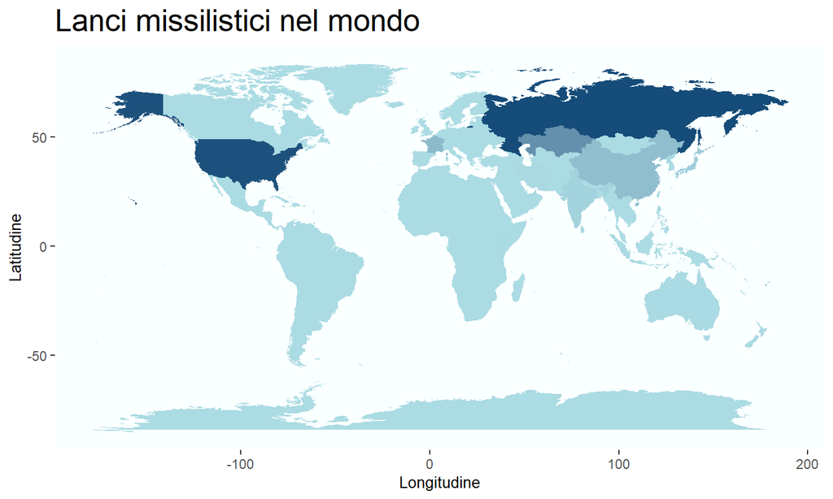

## Commento della prima analisi

I paesi che effettuano più lanci missilistici sono Russia e USA. Tuttavia, ai vertici della classifica ci sono anche altri paesi che hanno un impegno considerevole in questo tipo di missioni quali Francia e Kazakistan.

## Codice sorgente della seconda analisi

```r
library(dplyr)
library(stringr)
library(ggplot2)

#Dataset di partenza
originalDataset = read.csv("mission_launches.csv")

#Tramite una serie di mutate estrae l'anno dalla colonna Date
df1=originalDataset %>%
  mutate(Year =str_split_i(Date, ',',-1))%>%
  mutate(Year= str_trim(Year))%>%
  mutate(Year =str_split_i(Year, ' ',1))

#Raggruppo Mission_Status e Year e li conto così da avere per ogni anno quanto stati di missione di missione ci sono stati
df2= df1%>%
  group_by(Mission_Status, Year)%>%
  summarise(n = n())

#Plotta il subset df2 mappando sulle x gli anni estratti poco prima e sulle y mappa il conto dei vari stati delle missioni
ggplot(df2, mapping = aes(x= Year , y= n))+
  geom_bar(stat = "identity", aes(fill = Mission_Status), width = 0.8, position = position_stack())+ #Colora le    varie barre del barplot in base allo stato delle missioni
  labs(title = "Numero di stati che le missioni hanno assunto",
    y="Numero di occorrenze", x="Anni analizzati (1957-2020)")+
  theme(text = element_text(color = "black") #tra le parentesi del theme() ci sono degli elementi che rendono il   grafico più godibile e leggibile
    ,panel.background = element_rect(fill ="#FaFFFF")
    ,plot.background = element_rect(fill = "white")
    ,panel.grid = element_blank()
    ,plot.title = element_text(size = 20)
    ,axis.ticks = element_blank()
    ,axis.title.x = element_text(size = 10)
    ,axis.title.y = element_text(size = 10)
    ,axis.text.x = element_blank()
  )
```

## Output della seconda analisi

[figure not shown]

## Conclusioni

L’obiettivo del progetto è studiare l’esito dei lanci missilistici, per fare ciò ho deciso di :

- Capire quali sono le nazioni che si sono impegnati di più in questo determinato campo.
- Analizzare se effettivamente i lanci missilistici sono risultati utili o se si sono rivelati uno spreco di tempo e risorse.